# IT Rossmon

# Carga de datos

```r
# En este caso se hace una única carga de los archivos en formato csv que se obtienen de la pagina de SICOP, dado el tamaño de los archivos, lo recomendable es extraer año a año.


#SICOP2010 <-  read.csv("SICOP2010.csv", sep = ";", header = T,encoding="UTF-8")
#SICOP2011 <-  read.csv("SICOP2011.csv", sep = ";", header = T,encoding="UTF-8")
#SICOP2012 <-  read.csv("SICOP2012.csv", sep = ";", header = T,encoding="UTF-8")
#SICOP2013 <-  read.csv("SICOP2013.csv", sep = ";", header = T,encoding="UTF-8")
#SICOP2014 <-  read.csv("SICOP2014.csv", sep = ";", header = T,encoding="UTF-8")
#SICOP2015 <-  read.csv("SICOP2015.csv", sep = ";", header = T,encoding="UTF-8")
#SICOP2016 <-  read.csv("SICOP2016.csv", sep = ";", header = T,encoding="UTF-8")
#SICOP2017 <-  read.csv("SICOP2017.csv", sep = ";", header = T,encoding="UTF-8")
#SICOP2018 <-  read.csv("SICOP2018.csv", sep = ";", header = T,encoding="UTF-8")
#SICOP2019 <-  read.csv("SICOP2019.csv", sep = ";", header = T,encoding="UTF-8")
#SICOP2020 <-  read.csv("SICOP2020.csv", sep = ";", header = T,encoding="UTF-8")
#SICOP2021 <-  read.csv("SICOP2021.csv", sep = ";", header = T,encoding="UTF-8")
#SICOP2022 <-  read.csv("SICOP2022.csv", sep = ";", header = T,encoding="UTF-8")
```

```r
# Dato que tenemos licitaciones en dolares, necesitamos el tipo de cambio actualizado a la fecha, en este caso podemos descarga de la página del banco central el excel, es importante aclarar que en estos casos recomiendo dar el encoding porque eventualmente se pueden tener problemas principalmente con las fechas.



Tipo_de_Cambio  <-read_excel("Tipo_de_Cambio.xlsx")
```

```r
# Unimos todas las bases en una única base con todos los años.


#SICOP <- rbind(SICOP2010,SICOP2011,SICOP2012,SICOP2013,SICOP2014,SICOP2015,SICOP2016,SICOP2017,SICOP2018,SICOP2019,SICOP2020,SICOP2021,SICOP2022)


# Dado que los nombres son largos, tienen tildes entre otros, los cambiamos manualmente a nombres más cortos y significativos.



#nombres <- c("Fecha_notificacion","Descripcion","Numero_procedimiento","Institucion","Numero_contrato","Adjudicatario","Cedula_adjudicatario","Moneda","Monto","Modificaciones","Vigencia_contrato","Clasificacion_objeto","Tipo_modalidad","Tipo_Procedimiento","Firma_Contrato","Moneda_monto_estimado","Monto_estimado")

#colnames(SICOP) <- nombres



#SICOP$Fecha_notificacion <- as.POSIXct(SICOP$Fecha_notificacion,format ="%d/%m/%Y")

# Luego de hacer esto para actualizar la base, lo guardamos en formato RDS, un formato que respeta la estructura de las variables y son más eficientes que una base de otro tipo.

#saveRDS(SICOP,file = "DatosSICOP")

SICOP <-  readRDS("DatosSICOP")
```

# Manejo y transformación de Datos

```r
#Sys.setlocale("LC_TIME", "Spanish")

# Dado que el formato de tipo de cambio es otro que el de SICOP, hacemos el cambio aca para especificar que está españolizado.

# Esto se puede solucionar arreglandolo desde Excel, es más sencillo y se evite problemas de formato.

Tipo_de_Cambio$Fecha <- ymd(Tipo_de_Cambio$Fecha)


SICOP$Fecha_notificacion <- ymd(SICOP$Fecha_notificacion)


nom <- c("Fecha_notificacion","Compra","Venta")

colnames(Tipo_de_Cambio) <- nom



#  Filtramos por fecha de interes


SICOP2 <- SICOP %>% filter(Fecha_notificacion > "2018-01-01") %>% filter(Fecha_notificacion <"2022-09-01")

# Unimos los datos que tenemos del tipo de cambio


SICOP3  <-  merge(SICOP2, Tipo_de_Cambio, by="Fecha_notificacion")
```

# Analisis Descriptivo de la Base de Datos (EDA)

```r
# Primero filtraremos aquellas licitaciones de interes a la empresa con ciertas palabras claves
Empresas <-  SICOP3 %>% filter(grepl("software|Software|sofware|Sofware|Outtasking|Windows|Microsoft|microsoft|Microsof|microsof|Oracle|oracle|developer|Developer|Base de datos|Bases de datos|Base Datos|Base datos|BD|SQL|Outsourcing|outsourcing|desarrollador|.net|.netcore|c#|java|react",Descripcion))


Empresas <- Empresas %>% distinct()

#saveRDS(Empresas,file = "DatosFiltrados")
```

Veamos ahora la cantidad de instituciones y empresas que se les acredito la licitación.

```r
Instituciones <-  Empresas %>%  group_by(Institucion) %>% summarise("Conteo" =n())

Competencia <-  Empresas %>%  group_by(Adjudicatario) %>% summarise("Conteo" = n())
```

```r
datatable(Instituciones)
```

|  | Institucion | Conteo |
| --- | --- | --- |
| 1 | ASAMBLEA LEGISLATIVA | 18 |
| 2 | AUTORIDAD REGULADORA DE LOS SERVICIOS PUBLICOS | 36 |
| 3 | Asociación de Desarrollo Específica Pro Mantenimiento del Acueducto, construcción del salón Multiuso Cebadilla Turrúcares | 1 |
| 4 | B N SOCIEDAD ADMINISTRADORA DE FONDOS DE INVERSION SOCIEDAD ANONIMA | 8 |
| 5 | BANCO DE COSTA RICA | 79 |
| 6 | BANCO HIPOTECARIO DE LA VIVIENDA | 75 |
| 7 | BANCO POPULAR Y DE DESARROLLO COMUNAL | 13 |
| 8 | BCR CORREDORA DE SEGUROS SOCIEDAD ANONIMA | 1 |
| 9 | BCR PENSION OPERADORA DE PLANES DE PENSIONES COMPLEMENTARIAS SOCIEDAD ANONIMA | 1 |
| 10 | BCR Sociedad Administradora de Fondos de Inversión, S.A. | 1 |

[output cut: 191 more lines]

```r
datatable(Competencia)
```

|  | Adjudicatario | Conteo |
| --- | --- | --- |
| 1 | , Softline - AGT | 115 |
| 2 | 3-101-632776 SOCIEDAD ANONIMA | 2 |
| 3 | 3-101-723857 SOCIEDAD ANONIMA | 1 |
| 4 | 3-101-748418 SOCIEDAD ANONIMA | 1 |
| 5 | 3-101-812579 SOCIEDAD ANONIMA | 6 |
| 6 | 3-102-710265 SOCIEDAD DE RESPONSABILIDAD LIMITADA | 1 |
| 7 | A E C ELECTRONICA SOCIEDAD ANONIMA | 4 |
| 8 | A J SOLUCIONES SOCIEDAD ANONIMA | 40 |
| 9 | ABAQO TECHNOLOGIES SOCIEDAD ANONIMA | 1 |
| 10 | ABB S.A. | 2 |

[output cut: 774 more lines]

# Modelación usando RFM

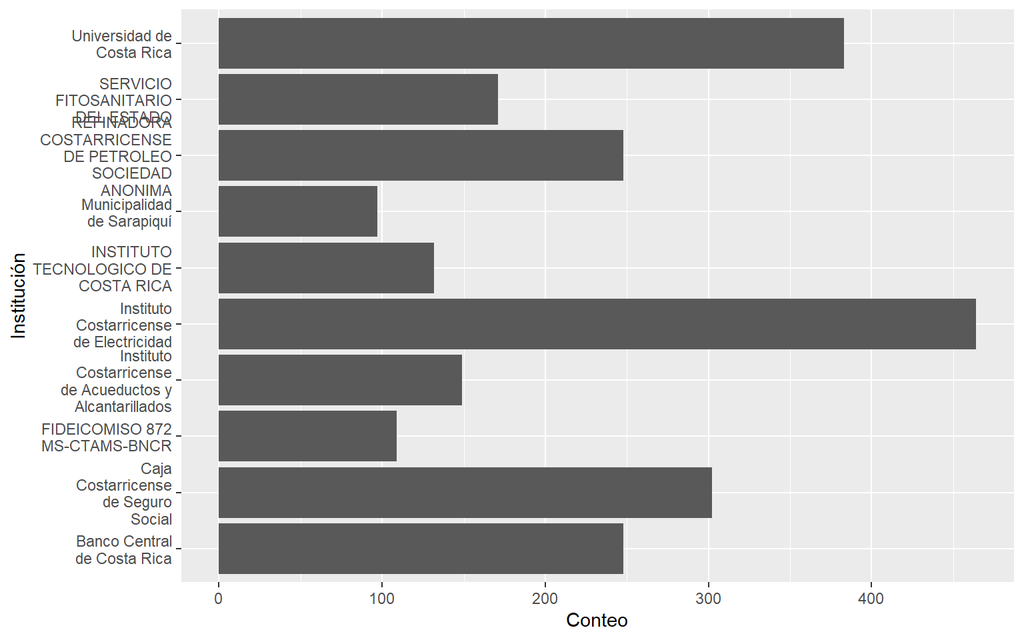

```r
Empresas$Moneda <-  as.factor(Empresas$Moneda)
Empresas$Moneda_monto_estimado <-  as.factor(Empresas$Moneda_monto_estimado)

Empresas$Monto <- as.numeric(gsub(",", ".", Empresas$Monto))



Empresas_2 <- Empresas %>% filter(Moneda == "CRC" | Moneda ==  "USD" ) %>%   mutate("MontoTotal" = ifelse(Moneda == "USD",Monto*Venta,Monto) )


EmpresasFinal <- Empresas_2[c(1,4,20)]

Empresas_Bar <-  Empresas_2 %>% group_by(Institucion) %>% summarise("Conteo" = n())


Empresas_Bar <-  Empresas_Bar[order(Empresas_Bar$Conteo,decreasing=TRUE),]

Empresas_Bar <- head(Empresas_Bar,10)

p <-   ggplot(Empresas_Bar, aes(x = Institucion, y = Conteo))+
    geom_col()+  theme(legend.position = "bottom") + coord_flip()
q <-  p + aes(stringr::str_wrap(Institucion, 15), Conteo) + xlab("Institución") + ylab("Conteo")
q
```

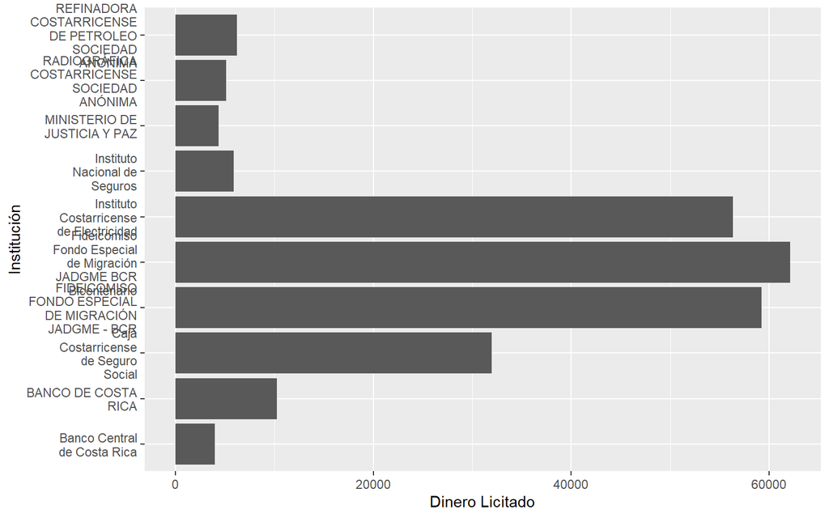

```r
Empresas_Bar <-  Empresas_2 %>% group_by(Institucion) %>% summarise("Dinero licitado" = sum(MontoTotal))


Empresas_Bar <-  Empresas_Bar[order(Empresas_Bar$`Dinero licitado`,decreasing=TRUE),]

Empresas_Bar <- head(Empresas_Bar,10)

p <-   ggplot(Empresas_Bar, aes(x = Institucion, y = `Dinero licitado`))+
    geom_col()+  theme(legend.position = "bottom") + coord_flip()
q <-  p + aes(stringr::str_wrap(Institucion, 15), `Dinero licitado`/1000000) + xlab("Institución") + ylab("Dinero Licitado")
q
```

```r
EmpresasFinal <- na.omit(EmpresasFinal)

rfm_result <- rfm_table_order(
                data = EmpresasFinal,
                customer_id = Institucion,
                revenue = MontoTotal,
                order_date = Fecha_notificacion,
                analysis_date = as.Date("2022/08/31")
                )
```

```r
segment_names <- c("Champions", "Loyal Customers", "Potential Loyalist",
  "New Customers", "Promising", "Need Attention", "About To Sleep",
  "At Risk", "Can't Lose Them", "Lost")

# We set the upper and lower bounds for recency, frequency, and monetary for the above segments
recency_lower <- c(4, 2, 3, 4, 3, 2, 2, 1, 1, 1)
recency_upper <- c(5, 5, 5, 5, 4, 3, 3, 2, 1, 2)
frequency_lower <- c(4, 3, 1, 1, 1, 2, 1, 2, 4, 1)
frequency_upper <- c(5, 5, 3, 1, 1, 3, 2, 5, 5, 2)
monetary_lower <- c(4, 3, 1, 1, 1, 2, 1, 2, 4, 1)
monetary_upper <- c(5, 5, 3, 1, 1, 3, 2, 5, 5, 2)

# We use the segments and the bounds we previously established to group our users into different segments
segment <- rfm_segment(rfm_result,
                       segment_names,
                       recency_lower,
                       recency_upper,
                       frequency_lower,
                       frequency_upper,
                       monetary_lower,
                       monetary_upper)

segment %>%
  kable() %>%
  kable_classic_2()
```

| customer_id | segment | rfm_score | transaction_count | recency_days | amount | recency_score | frequency_score | monetary_score |
| --- | --- | --- | --- | --- | --- | --- | --- | --- |
| ASAMBLEA LEGISLATIVA | Champions | 444 | 18 | 92 | 128201602.03 | 4 | 4 | 4 |
| AUTORIDAD REGULADORA DE LOS SERVICIOS PUBLICOS | Loyal Customers | 244 | 36 | 384 | 178493512.64 | 2 | 4 | 4 |
| Asociación de Desarrollo Específica Pro Mantenimiento del Acueducto, construcción del salón Multiuso Cebadilla Turrúcares | About To Sleep | 212 | 1 | 320 | 37314888.49 | 2 | 1 | 2 |
| B N SOCIEDAD ADMINISTRADORA DE FONDOS DE INVERSION SOCIEDAD ANONIMA | Potential Loyalist | 322 | 8 | 177 | 25187196.84 | 3 | 2 | 2 |
| BANCO DE COSTA RICA | Champions | 455 | 79 | 51 | 10244656586.33 | 4 | 5 | 5 |
| BANCO HIPOTECARIO DE LA VIVIENDA | Champions | 455 | 75 | 55 | 824699132.19 | 4 | 5 | 5 |
| BANCO POPULAR Y DE DESARROLLO COMUNAL | Loyal Customers | 235 | 13 | 497 | 3120260401.65 | 2 | 3 | 5 |
| BCR CORREDORA DE SEGUROS SOCIEDAD ANONIMA | Others | 113 | 1 | 1163 | 114720575.53 | 1 | 1 | 3 |
| BCR PENSION OPERADORA DE PLANES DE PENSIONES COMPLEMENTARIAS SOCIEDAD ANONIMA | About To Sleep | 211 | 1 | 530 | 180781.90 | 2 | 1 | 1 |
| BCR Sociedad Administradora de Fondos de Inversión, S.A. | About To Sleep | 211 | 1 | 519 | 363103.70 | 2 | 1 | 1 |
| BCR VALORES SOCIEDAD ANONIMA | Lost | 111 | 1 | 653 | 141445.44 | 1 | 1 | 1 |
| BENEMERITO CUERPO DE BOMBEROS DE COSTA RICA | Champions | 555 | 39 | 12 | 1907817130.42 | 5 | 5 | 5 |
| BN SOCIEDAD CORREDORA DE SEGUROS SOCIEDAD ANONIMA | Potential Loyalist | 321 | 3 | 149 | 1234260.84 | 3 | 2 | 1 |
| BN VITAL OPERADORA DE PLANES DE PENSIONES COMPLEMENTARIAS SOCIEDAD ANONIMA | Loyal Customers | 233 | 10 | 418 | 83759714.59 | 2 | 3 | 3 |
| BN Valores Puesto de Bolsa, S.A. | Potential Loyalist | 321 | 4 | 278 | 8466047.01 | 3 | 2 | 1 |
| Banco Central de Costa Rica | Champions | 555 | 248 | 22 | 3979220525.44 | 5 | 5 | 5 |
| Banco Nacional de Costa Rica | Lost | 111 | 2 | 1359 | 6264000.00 | 1 | 1 | 1 |
| CABLEVISION DE COSTA RICA CVCR SOCIEDAD ANONIMA | Lost | 111 | 2 | 1611 | 4691114.40 | 1 | 1 | 1 |
| COLEGIO UNIVERSITARIO DE CARTAGO | Lost | 111 | 1 | 637 | 3854529.00 | 1 | 1 | 1 |
| COLEGIO UNIVERSITARIO DE LIMON | At Risk | 124 | 3 | 1076 | 184492985.32 | 1 | 2 | 4 |
| COMISION NACIONAL DE PREVENCION DE RIESGOS Y ATENCION DE EMERGENCIAS | Champions | 555 | 47 | 34 | 1070418667.25 | 5 | 5 | 5 |
| COMITÉ CANTONAL DE DEPORTES Y RECREACIÓN DE CARTAGO | Potential Loyalist | 321 | 5 | 114 | 4412471.45 | 3 | 2 | 1 |
| COMPAÑÍA NACIONAL DE FUERZA Y LUZ SOCIEDAD ANÓNIMA | Loyal Customers | 435 | 12 | 44 | 731192182.04 | 4 | 3 | 5 |
| CONSEJO DE SALUD OCUPACIONAL | Others | 114 | 2 | 1280 | 202986269.44 | 1 | 1 | 4 |
| CONSEJO DE SEGURIDAD VIAL | Champions | 555 | 54 | 1 | 1087006348.29 | 5 | 5 | 5 |
| CONSEJO DE TRANSPORTE PUBLICO | Loyal Customers | 245 | 25 | 334 | 3711067756.12 | 2 | 4 | 5 |
| CONSEJO NACIONAL DE CONCESIONES | About To Sleep | 221 | 3 | 345 | 7824113.75 | 2 | 2 | 1 |
| CONSEJO NACIONAL DE LA PERSONA ADULTA MAYOR | Lost | 112 | 2 | 628 | 20526489.78 | 1 | 1 | 2 |
| CONSEJO NACIONAL DE PERSONAS CON DISCAPACIDAD | At Risk | 122 | 3 | 839 | 15306919.21 | 1 | 2 | 2 |
| CONSEJO NACIONAL DE RECTORES | Potential Loyalist | 323 | 7 | 271 | 70632257.59 | 3 | 2 | 3 |

[output cut: 171 more lines]

# Uso de Modelos de clusters

## PCA

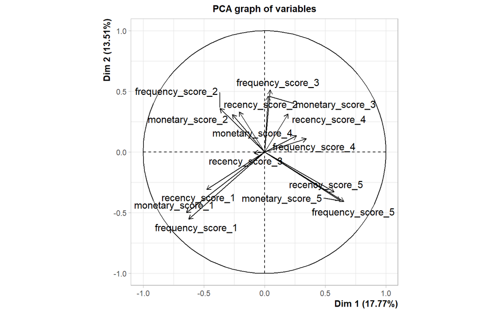

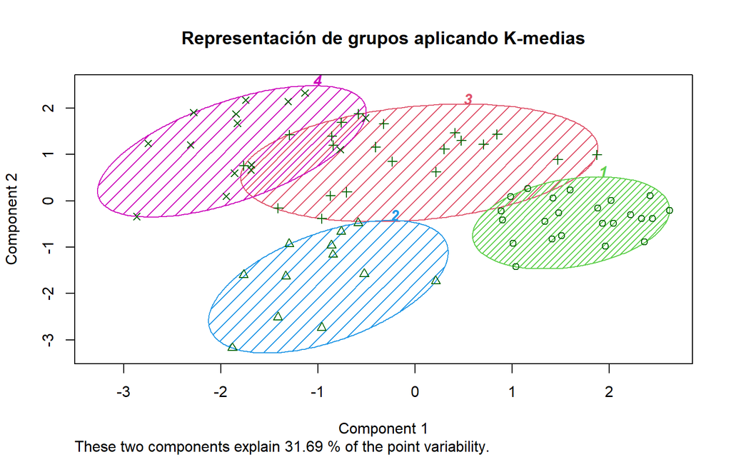

# UMAP

[interactive chart not shown]

# Proyección Serie de Tiempo

```r
datos2 <- Empresas_2 %>% group_by(Date=floor_date(Fecha_notificacion, "month")) %>%
  summarise(Conteo = n())
```

```r
serie <- ts(datos2$Conteo, start = c(2018,1), freq = 12)
```

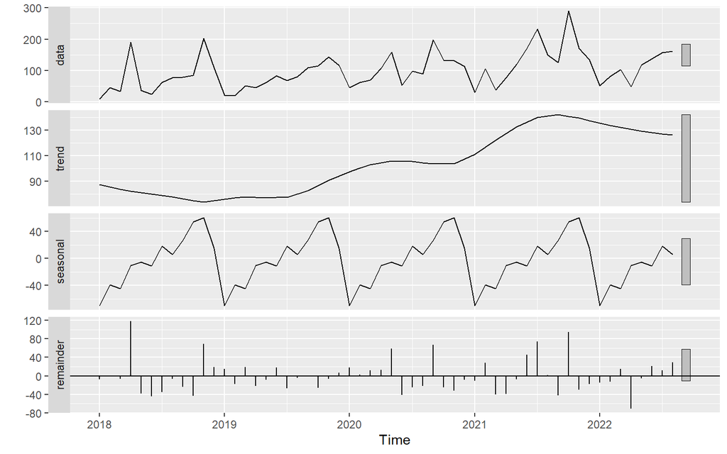

```r
autoplot(stl(serie, s.window = "periodic"))
```

```r
serie.train <- head(serie,50)
serie.test <- tail(serie, 6)
```

```r
res <- spec.pgram(serie.train, log = "no", plot = F)
pos <- order(res$spec, res$freq, decreasing = TRUE)  # Ordenamos de mayor a menor.
mejores3 <- pos[pos != 1][1:3]  # Ignoramos la posición 1 y tomamos las 3 primeras posiciones.
frecuencias <- res$freq[mejores3]  # Obtenemos la frecuencia de las 3 primeras posiciones.
periodos <- (12)/frecuencias  # Obtenemos los 3 periodos más importantes
periodos
```

```
## [1] 12.50  6.25 10.00
```

ARIMA

```r
auto.arima(serie.train)
```

```
## Series: serie.train
## ARIMA(0,1,1)(1,0,0)[12]
##
## Coefficients:
##           ma1    sar1
##       -0.9048  0.4763
## s.e.   0.0593  0.1638
##
## sigma^2 = 2817:  log likelihood = -265.37
## AIC=536.73   AICc=537.26   BIC=542.41
```

Ahora aplicamos una calibración a fuerza computacional para encontrar un mejor modelo ARIMA, este nos arroja el siguiente resultado

```r
#calibrar.arima(serie.train, serie.test, periodo = 6)

#Call:
#arima(x = datos, order = c(3, 1, 0), seasonal = list(order = c(3, 0, 0), period = 6))

#Coefficients:
#          ar1      ar2      ar3     sar1    sar2    sar3
#      -0.5756  -0.4255  -0.3288  -0.3113  0.3766  0.1943
#s.e.   0.1612   0.1585   0.1496   0.1663  0.2046  0.2034

#sigma^2 estimated as 2753:  log likelihood = -265.42,  aic = 544.84

## Corrida 2
```

Holt-Winters

Al igual que con ARIMA, aplicamos el método brindado por R, pero también aplicamos fuerza computacional y así encontrar el mejor modelo Holt-Winters.

```
## Holt-Winters exponential smoothing with trend and additive seasonal component.
##
## Call:
## HoltWinters(x = datos, alpha = 0.5, beta = 0.9, gamma = 0.1)
##
## Smoothing parameters:
##  alpha: 0.5
##  beta : 0.9
##  gamma: 0.1
##
## Coefficients:
##           [,1]
## a    86.542500
## b    14.009454
## s1  -29.635547
## s2  -32.620929
## s3  -12.425913
## s4    2.963618
## s5  -11.175548
## s6   -6.472407
## s7    3.980593
## s8   17.345227
## s9  112.807639
## s10  43.139095
## s11 -43.798936
## s12 -42.548329
```

# Redes Neuronales

Aqui aplicamos el paquete brindado por R de forecast, que usa la función Nnetar, adicionalmente indicamos 5 nodos. Esto último se puede modificar, pero luego de probar varios nodos, encontramos 5 como el más óptimo.

```r
modelo.redes <- nnetar(serie.train, size = 5)
pred.redes <- predict(modelo.redes, h = 6, PI = T)
```

# Tabla y gráfico de errores

Ahora hagamos una comparación con todos los métodos utilizados, recordemos que buscamos reducir el MSE, tener la correlación más cercana a 1 y el error relativo más bajo.

```
##                          MSE     RMSE         RE      CORR
## AUTO.ARIMA         1508.0334 38.83341 0.25619835        NA
## ARIMA FUERZA BRUTA  140.3093 11.84522 0.08449648 0.9646330
## HOLT-WINTERS       2575.5405 50.74978 0.35855787 0.7205684
## HW FUERZA BRUTA     386.4652 19.65872 0.12277638 0.8577671
## REDES              1231.9120 35.09860 0.23801430 0.6947068
```

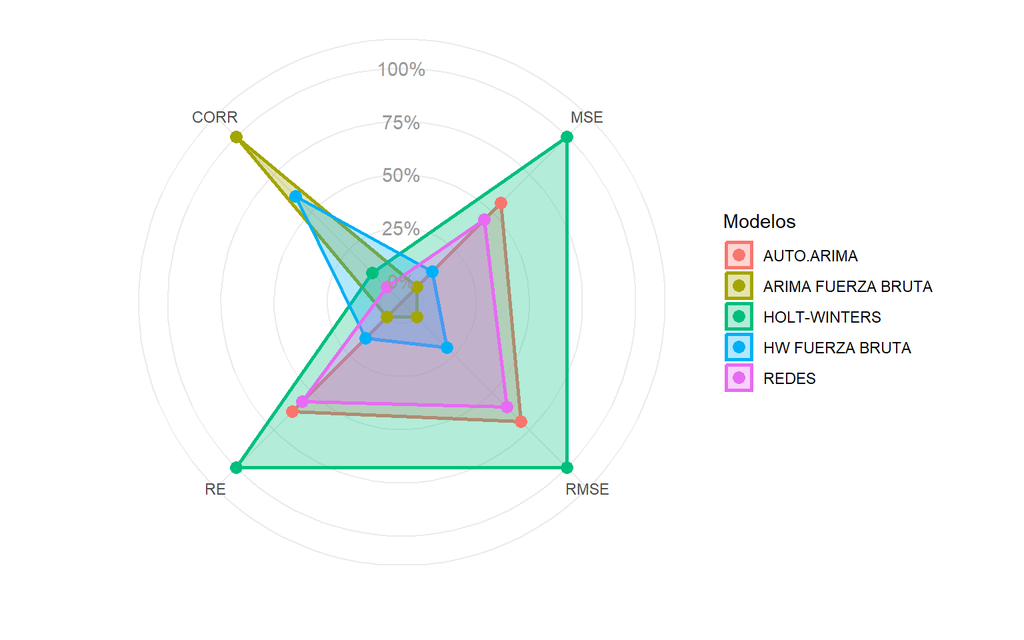

No cabe duda que el modelo encontrado a fuerza computacional por ARIMA es el que mejores resultados arroja.

## Gráfico de predicción

[interactive chart not shown]

```r
modelo.arima.calibrado <- arima(x = serie, order = c(3, 1, 0), seasonal = list(order = c(3, 0, 0), period = 6))
pred.arima.calibrado <- predict(modelo.arima.calibrado, n.ahead = 12)




fechas <-  seq(as.Date("2018-01-01"), as.Date("2023-08-01"), by="months")

serion <- serie

res <- ts.union(serion, pred.arima.calibrado$pred)
res <- data.frame(res)
res$d <- fechas
q <-  res |> e_charts(x = d) |> e_datazoom() |> e_tooltip(trigger = 'axis') |>
  e_line(serie = serion, name = 'Serie') |>
  e_line(serie = pred.arima.calibrado.pred, name = 'Predicción')
q
```

[interactive chart not shown]